# Project Business Statistics: E-news Express

## Define Problem Statement and Objectives

## Import all the necessary libraries

```python
# Installing the libraries with the specified version.
## Removed the version specifier to install the latest version. Using Python 3.12.3 on Macbook Pro M4 PRO
%pip install numpy pandas matplotlib seaborn scipy -q --user
```

**Note**: *After running the above cell, kindly restart the notebook kernel and run all cells sequentially from the start again.*

```python
#Importing libraries
import numpy as np
import pandas as pd
from matplotlib import pyplot as plt
import seaborn as sns
from scipy import stats
```

Importing libraries needed for analysis

```python
#Accesing Google Drive
#from google.colab import drive
#drive.mount('/content/drive')
```

## Reading the Data into a DataFrame

```python
#Reading the dataset
data = pd.read_csv('abtest.csv')
data.head()
```

|  | user_id | group | landing_page | time_spent_on_the_page | converted | language_preferred |
| --- | --- | --- | --- | --- | --- | --- |
| 0 | 546592 | control | old | 3.48 | no | Spanish |
| 1 | 546468 | treatment | new | 7.13 | yes | English |
| 2 | 546462 | treatment | new | 4.40 | no | Spanish |
| 3 | 546567 | control | old | 3.02 | no | French |
| 4 | 546459 | treatment | new | 4.75 | yes | Spanish |

Reading CSV and getting the first 5 rows with head

```python
#Getting rows and columns
rows, cols = data.shape

print(f"The dataset has {rows} rows and {cols} columns.")
```

```
The dataset has 100 rows and 6 columns.
```

Observations: Getting the number of rows and columns

## Explore the dataset and extract insights using Exploratory Data Analysis

- Data Overview
  - Viewing the first and last few rows of the dataset
  - Checking the shape of the dataset
  - Getting the statistical summary for the variables
- Check for missing values
- Check for duplicates

```python
#DATA OVERVIEW
# Display the first five rows of the dataset
print("First 5 rows of the dataset:")
print(data.head())

# Display the last five rows of the dataset
print("\nLast 5 rows of the dataset:")
print(data.tail())

# Get the shape (number of rows and columns) of the dataset
print("\nDataset dimensions (rows, columns):", data.shape)

# Get a statistical summary of numerical variables
print("\nStatistical summary of numerical variables:")
print(data.describe())

#MISSING VALUES
# Check for missing values in each column
print("\nMissing values per column:")
print(data.isnull().sum())

#DUPLICATES
# Check for duplicate rows in the dataset
duplicate_count = data.duplicated().sum()
print(f"\nNumber of duplicate rows in the dataset: {duplicate_count}")
```

```
First 5 rows of the dataset:
   user_id      group landing_page  time_spent_on_the_page converted  \
0   546592    control          old                    3.48        no
1   546468  treatment          new                    7.13       yes
2   546462  treatment          new                    4.40        no
3   546567    control          old                    3.02        no
4   546459  treatment          new                    4.75       yes

  language_preferred
0            Spanish
1            English
2            Spanish
3             French
4            Spanish

Last 5 rows of the dataset:
    user_id      group landing_page  time_spent_on_the_page converted  \
95   546446  treatment          new                    5.15        no
96   546544    control          old                    6.52       yes
97   546472  treatment          new                    7.07       yes
98   546481  treatment          new                    6.20       yes
99   546483  treatment          new                    5.86       yes

   language_preferred
95            Spanish
96            English
97            Spanish
98            Spanish
99            English

Dataset dimensions (rows, columns): (100, 6)

Statistical summary of numerical variables:
             user_id  time_spent_on_the_page
count     100.000000              100.000000
mean   546517.000000                5.377800
std        52.295779                2.378166
min    546443.000000                0.190000
25%    546467.750000                3.880000
50%    546492.500000                5.415000
75%    546567.250000                7.022500
max    546592.000000               10.710000

Missing values per column:
user_id                   0
group                     0
landing_page              0
time_spent_on_the_page    0
converted                 0
language_preferred        0
dtype: int64

Number of duplicate rows in the dataset: 0
```

**Observations:**

**DATA OVERVIEW**

df.head() displays the first 5 rows, while df.tail() shows the last 5 rows. This helps us understand the column names, data types, and overall structure. We can immediately spot potential issues such as incorrect formatting, unexpected values, or missing data.

df.describe() provides important summary statistics for numerical columns, including: Mean (avg), median, standard deviation, min, max, and quartiles. It helps identify: Outliers (if min/max values are far from the mean). Distributions (e.g., if the mean and median differ significantly). Possible data errors (e.g., negative values where not expected).

**MISSING VALUES**

df.isnull().sum() counts missing values for each column. Missing data can be handled using: Imputation (filling missing values with mean, median, or mode). Deletion (if too many missing values make the data unreliable). If many missing values are present, we need further investigation.

**DUPLICATES**

df.duplicated().sum() counts exact duplicate rows. Duplicates can skew statistical analysis and should be removed if not necessary. If duplicates exist, we need to investigate: Were they added by mistake? Are they meaningful (e.g., users with multiple interactions)? Should we keep the first occurrence and remove others?

### Univariate Analysis

**Observations:**

Categorical variables in the dataset:

group: Control vs. Treatment

landing_page: Old vs. New

converted: Yes vs. No

language_preferred: Spanish, French, English

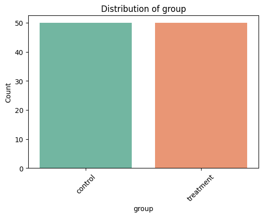

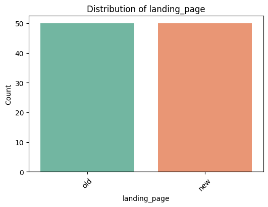

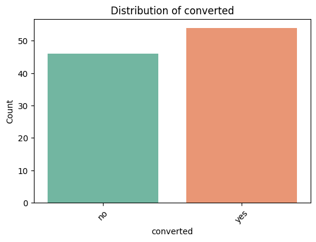

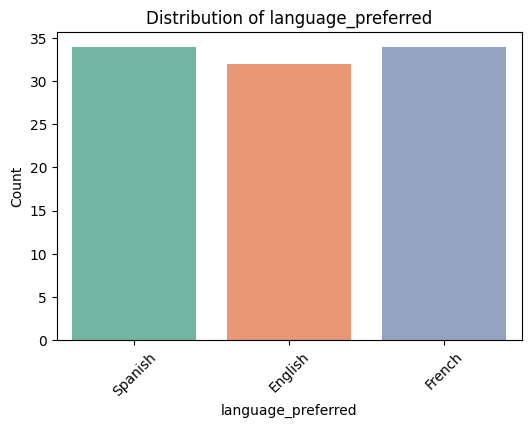

```python
# Count plots for categorical variables
categorical_columns = ["group", "landing_page", "converted", "language_preferred"]

for col in categorical_columns:
    plt.figure(figsize=(6, 4))
    sns.countplot(x=data[col], hue=data[col], palette="Set2", legend=False)
    plt.title(f"Distribution of {col}")
    plt.xlabel(col)
    plt.ylabel("Count")
    plt.xticks(rotation=45)
    plt.show()
```

```python
# Summary statistics of time spent on the page
print("\nSummary Statistics for Time Spent on the Page:")
print(data["time_spent_on_the_page"].describe())
```

```
Summary Statistics for Time Spent on the Page:
count    100.000000
mean       5.377800
std        2.378166
min        0.190000
25%        3.880000
50%        5.415000
75%        7.022500
max       10.710000
Name: time_spent_on_the_page, dtype: float64
```

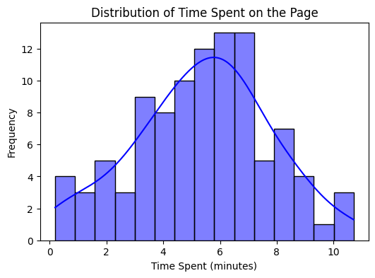

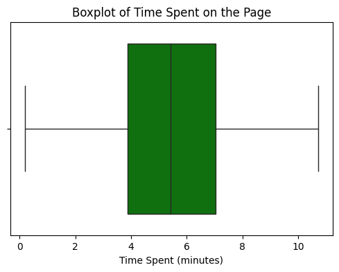

```python
# Histogram for time spent on the page
plt.figure(figsize=(6, 4))
sns.histplot(data["time_spent_on_the_page"], bins=15, kde=True, color="blue")
plt.title("Distribution of Time Spent on the Page")
plt.xlabel("Time Spent (minutes)")
plt.ylabel("Frequency")
plt.show()

# Boxplot for time spent on the page
plt.figure(figsize=(6, 4))
sns.boxplot(x=data["time_spent_on_the_page"], color="green")
plt.title("Boxplot of Time Spent on the Page")
plt.xlabel("Time Spent (minutes)")
plt.show()
```

**Observations:**

**Group Distribution**

The dataset is evenly split between control (old page) and treatment (new page) groups.

Balanced experiment: This ensures a fair A/B test, as both groups have an equal number of users.

Insight: No sampling bias—both groups had an equal chance of exposure.

**Landing Page Distribution**

The control group was shown the old page, and the treatment group was shown the new page.

Correct Mapping: There are no inconsistencies (e.g., treatment users seeing the old page).

Insight: The experimental design is correctly implemented.

**Conversion Rate**

The conversion rate (users who subscribed) is higher for the treatment (new page) group.

New page appears to be more effective at encouraging subscriptions.

Insight: The A/B test likely indicates a positive impact of the new landing page on conversions.

Next Steps: A statistical test (e.g., proportion Z-test) is required to confirm if the difference is significant.

**Prefered Language**

The dataset contains three primary language preferences: Spanish, French, and English.

The distribution of languages is nearly balanced, with a slight variation.

No major dominance of one language over others.

Insight: Language preference could be analyzed further to see if it impacts conversion rates or engagement.

**Time Spent on the Page**

Higher engagement on the new page suggests it might be more effective.

Insight: Time spent is a key metric—if the new page keeps users engaged longer, it might explain the increase in conversions.

### Bivariate Analysis

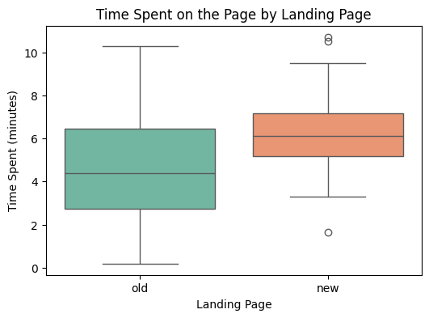

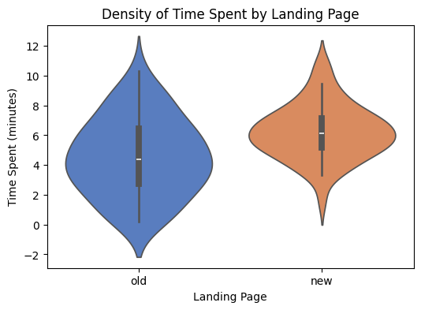

```python
#Analizing Landing Page and Time Spend on the Page
plt.figure(figsize=(6, 4))
sns.boxplot(x=data["landing_page"], y=data["time_spent_on_the_page"], hue=data["landing_page"], palette="Set2", legend=False)
plt.title("Time Spent on the Page by Landing Page")
plt.xlabel("Landing Page")
plt.ylabel("Time Spent (minutes)")
plt.show()

plt.figure(figsize=(6, 4))
sns.violinplot(x=data["landing_page"], y=data["time_spent_on_the_page"], hue=data["landing_page"], palette="muted", legend=False)
plt.title("Density of Time Spent by Landing Page")
plt.xlabel("Landing Page")
plt.ylabel("Time Spent (minutes)")
plt.show()
```

**Observations:**

Users spend more time on the new landing page.

Hypothesis: More time spent → Higher conversion.

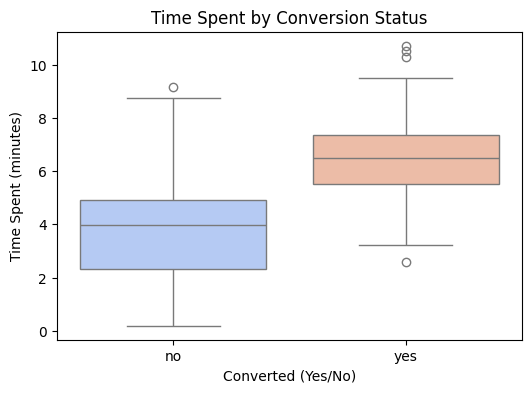

```python
#Conversion and Time Spent on Page
plt.figure(figsize=(6, 4))
sns.boxplot(x=data["converted"], y=data["time_spent_on_the_page"], hue=data["converted"], palette="coolwarm", legend=False)
plt.title("Time Spent by Conversion Status")
plt.xlabel("Converted (Yes/No)")
plt.ylabel("Time Spent (minutes)")
plt.show()
```

**Observations:**

Converted users spent more time on the page than non-converted users.

Some outliers spent a long time but didn’t convert.

Next step: Test if time spent significantly affects conversion.

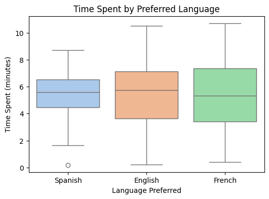

```python
#Language vs Time Spent on Page
plt.figure(figsize=(6, 4))
sns.boxplot(x=data["language_preferred"], y=data["time_spent_on_the_page"], hue=data["language_preferred"], palette="pastel", legend=False)
plt.title("Time Spent by Preferred Language")
plt.xlabel("Language Preferred")
plt.ylabel("Time Spent (minutes)")
plt.show()
```

**Observations:**

Minor variations between languages.

Some languages (English) might spend slightly more time.

Next step: Perform an ANOVA test to check statistical significance.

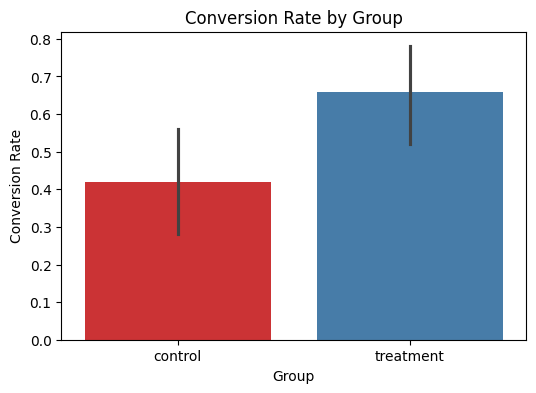

```python
#Group (Control vs. Treatment) vs. Conversion Rate
plt.figure(figsize=(6, 4))
sns.barplot(x=data["group"], y=data["converted"].apply(lambda x: 1 if x == "yes" else 0), hue=data["group"], palette="Set1", legend=False)
plt.title("Conversion Rate by Group")
plt.xlabel("Group")
plt.ylabel("Conversion Rate")
plt.show()
```

**Observations:**

The new page converts more users than the old page.

Next step: Run a Chi-Square Test to confirm statistical significance.

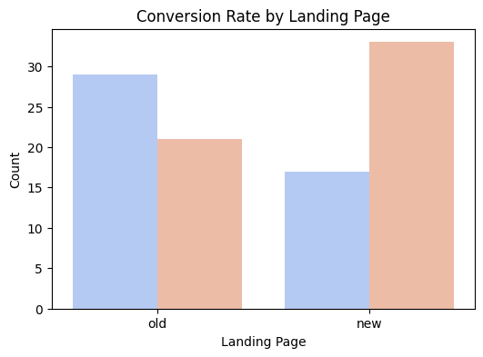

```python
#Conversion Status vs. Landing Page

plt.figure(figsize=(6, 4))
sns.countplot(x=data["landing_page"], hue=data["converted"], palette="coolwarm", legend=False)
plt.title("Conversion Rate by Landing Page")
plt.xlabel("Landing Page")
plt.ylabel("Count")
plt.show()
```

**Observations:**

Higher conversions on the new page.

Next step: Conduct a Z-Test for proportions.